# Rýchle a temporálne metódy

Blok 7 · cvičenia 17 – 18

Senzometria v R · SaIT

## Prečo rýchle metódy?

|  | deskriptívny profil | CATA | napping |
| --- | --- | --- | --- |
| hodnotitelia | 8 – 12 trénovaných | 40 – 100 spotrebiteľov | 15 – 50 |
| príprava | mesiace tréningu | žiadna | žiadna |
| úloha | intenzita deskriptorov | začiarknuť platné atribúty | rozložiť vzorky na papier |
| analýza | ANOVA, PCA | Cochranov Q, CA | MFA |

## CATA – Check-All-That-Apply

```r
set.seed(2024)
atributy <- c("sladky", "kysly", "kremovy", "ovocny", "husty", "umely")
p <- rbind(A = c(.7, .2, .8, .3, .6, .1), B = c(.3, .7, .3, .2, .2, .2),
           C = c(.6, .3, .4, .8, .3, .5), D = c(.5, .4, .6, .5, .7, .1))
colnames(p) <- atributy
cata <- expand.grid(spotrebitel = factor(1:40), produkt = factor(rownames(p)))
for (a in atributy) cata[[a]] <- rbinom(nrow(cata), 1, p[as.character(cata$produkt), a])
tabulka <- sapply(atributy, function(a) tapply(cata[[a]], cata$produkt, sum))
tabulka
```

```
  sladky kysly kremovy ovocny husty umely
A     27     8      26     16    26     2
B     10    26      15      7     5    13
C     25     7      21     33     9    18
D     19    20      28     23    29     2
```

## Cochranov Q test

```r
q_p <- sapply(atributy, function(a) {
  d <- data.frame(y = cata[[a]], produkt = cata$produkt, spotrebitel = cata$spotrebitel)
  CochranQTest(y ~ produkt | spotrebitel, data = d)$p.value
})
round(q_p, 4)
```

```
 sladky   kysly kremovy  ovocny   husty   umely
 0.0009  0.0000  0.0164  0.0000  0.0000  0.0000
```

Obdoba McNemarovho testu pre viac vzoriek: tí istí spotrebitelia hodnotia všetky produkty → spotrebiteľ je **blok**.

## Mapa CATA

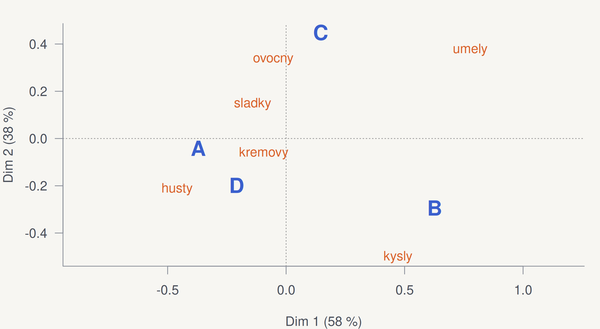

```r
ca <- CA(tabulka, graph = FALSE)
plot(rbind(ca$row$coord[, 1:2], ca$col$coord[, 1:2]), type = "n", asp = 1,
     xlab = sprintf("Dim 1 (%.0f %%)", ca$eig[1, 2]), ylab = sprintf("Dim 2 (%.0f %%)", ca$eig[2, 2]))
abline(h = 0, v = 0, lty = 3, col = "grey60")
text(ca$row$coord[, 1:2], rownames(tabulka), col = pal[3], font = 2, cex = 1.6)
text(ca$col$coord[, 1:2], colnames(tabulka), col = pal[2])
```

## Napping – projektívne mapovanie

- všetky vzorky naraz, hárok 60 × 40 cm
- podobné vzorky blízko, odlišné ďaleko
- zaznamenajú sa súradnice X, Y
- každý hodnotiteľ = skupina 2 premenných → **MFA**

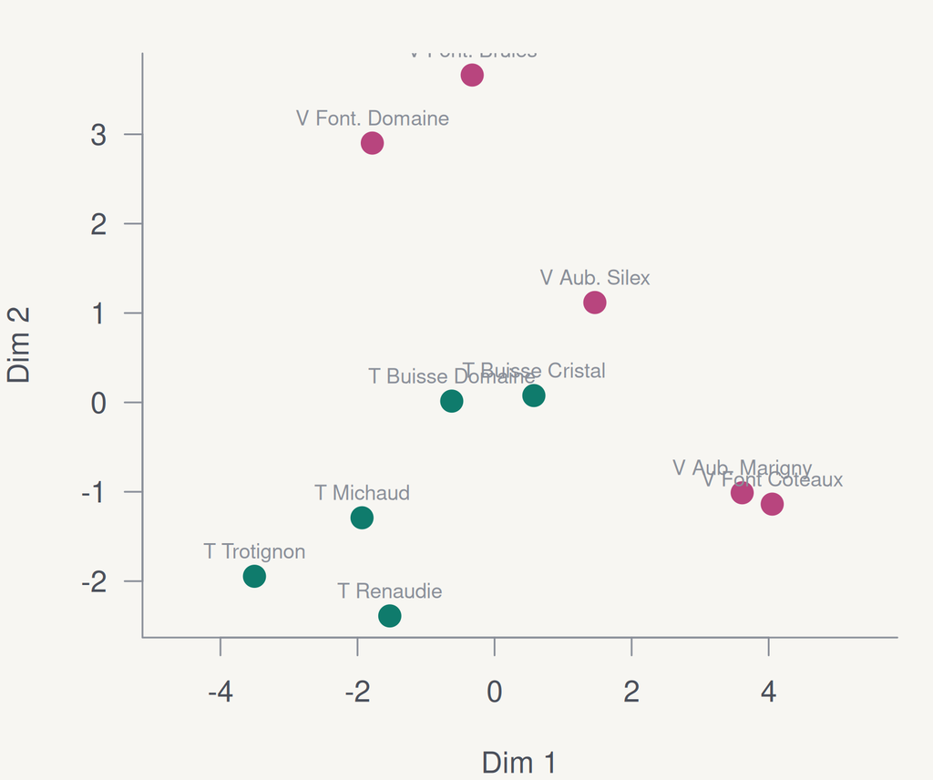

Konsenzuálna mapa 10 vín: MFA vyváži hodnotiteľov a nájde spoločnú konfiguráciu. Zelené = Touraine, fialové = Vouvray.

## KVÍZ Škálovať súradnice?

V MFA pre napping používame `type = "c"` (neškálované). Prečo nie `"s"`?

Súradnice sú v **centimetroch na tom istom hárku** – vzdialenosť 5 cm v smere X aj Y znamená rovnakú mieru odlišnosti. Škálovanie by túto informáciu skreslilo.

## Vnem sa mení v čase

|  | TDS | TCATA |
| --- | --- | --- |
| otázka | ktorý vnem je **teraz dominantný**? | ktoré vnemy **teraz vnímate**? |
| výber | práve jeden atribút | ľubovoľný počet |
| výstup | miera dominancie | podiel citácií |

Dáta zbierajú aplikácie `TDS_app.R` a `TCATA_app.R` v priečinku `Senzometricke_appky/`.

## TDS krivky

**Kód**

```r
set.seed(18)
atr <- c("sladky", "kysly", "horky", "ovocny", "adstringentny"); cas <- 0:60; n <- 30
vaha <- cbind(dnorm(cas, 8, 8), dnorm(cas, 18, 8), dnorm(cas, 40, 12), dnorm(cas, 22, 10), dnorm(cas, 52, 10))
tds <- t(sapply(1:n, function(h) apply(vaha, 1, function(w) sample(atr, 1, prob = w + 1e-4))))
dom <- sapply(atr, function(a) colMeans(tds == a))
hranica <- 0.2 + 1.645 * sqrt(0.2 * 0.8 / n)
matplot(cas, dom, type = "l", lty = 1, lwd = 3, col = pal, ylim = c(0, 1), xlab = "čas (s)", ylab = "miera dominancie")
abline(h = c(0.2, hranica), lty = c(3, 2), col = c("grey50", pal[2]))
legend("topright", atr, col = pal, lwd = 3, bty = "n", cex = 0.8)
```

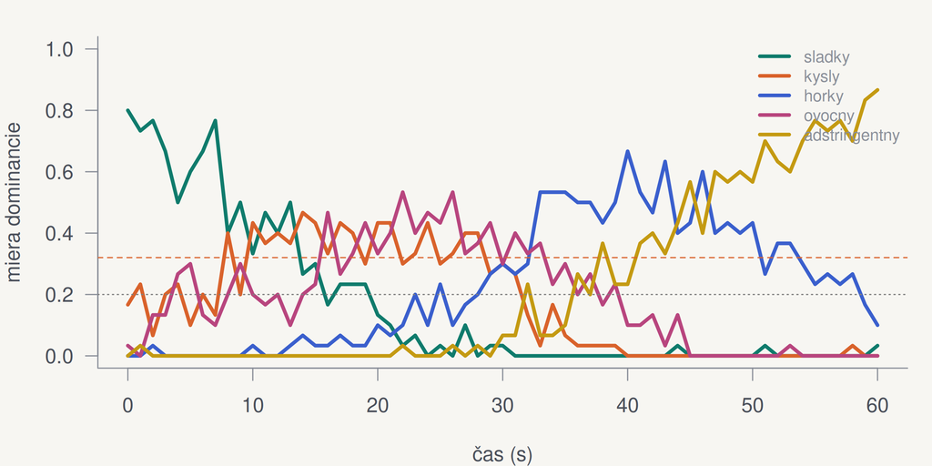

Atribút je preukazne dominantný nad červenou hranicou P₀ + 1,645·√(P₀(1 − P₀)/n) = 0.32.

## TCATA: porovnanie dvoch produktov

- krivky oboch produktov v jednom grafe
- v každom čase Fisherov test podielu citácií
- za rozdiel považujeme **súvislý interval**, nie osamotené body (desiatky testov!)

Pri reálnych dátach hodnotitelia prehĺtajú v rôznom čase → čas sa často **štandardizuje** (0 = prvý výber, 1 = koniec záznamu). Balík `tempR`.

## Zhrnutie

- **CATA**: binárne dáta → Cochranov Q (rozdiely), CA (mapa).
- **Napping**: súradnice X, Y → MFA, konsenzuálna mapa.
- **TDS / TCATA**: krivky v čase, hranica významnosti, pozor na mnohonásobné testovanie.
- Rýchle metódy: menej presné, ale lacné a rýchle – vhodné na skríning.

Teória 17 Teória 18